# SERIES TEMPORALES - Deshaucis

Guillem Miralles - Miguel Payà

29/9/2020

## Serie con estacionalidad:

```r
#LECTURA DEL FICHERO:
library(readr)
DBDesahucios <- read_delim("Datos.csv", ";", escape_double = FALSE,
    trim_ws = TRUE)
#SELECCIONAMOS LOS DATOS
DBDesahucios <- DBDesahucios[1:28,]
#Vamos a eliminar el 1er trimestre de 2020 ya que al no estar todos los trimestres, no nos interesa
names (DBDesahucios) = c("Anyo", "Periodo", "Desahucios","Fecha")
head(DBDesahucios)
```

```
## # A tibble: 6 x 4
##   Anyo  Periodo     Desahucios Fecha
##   <chr> <chr>            <dbl> <chr>
## 1 2013  Trimestre 1       19.5 2013 - Trimestre 1
## 2 2013  Trimestre 2       18.1 2013 - Trimestre 2
## 3 2013  Trimestre 3       12.4 2013 - Trimestre 3
## 4 2013  Trimestre 4       17.2 2013 - Trimestre 4
## 5 2014  Trimestre 1       18.5 2014 - Trimestre 1
## 6 2014  Trimestre 2       18.7 2014 - Trimestre 2
```

### 1.Análisis descriptivo:

```r
#Vamos a realizar una estadistica descriptiva de los datos:
attach(DBDesahucios)
max(Desahucios)
```

```
## [1] 19.468
```

```r
min(Desahucios)
```

```
## [1] 10.173
```

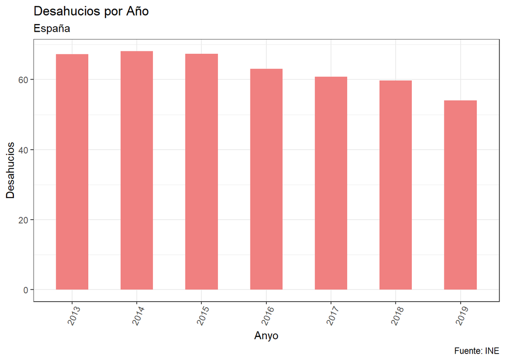

```r
library(ggplot2)
theme_set(theme_bw())

# Draw plot
g1 <- ggplot(DBDesahucios, aes(x=Anyo, y=Desahucios)) +
  geom_bar(stat="identity", width=.5, fill="lightcoral") +
  labs(title="Desahucios por Año",
       subtitle="España",
       caption="Fuente: INE") +
  theme(axis.text.x = element_text(angle=65, vjust=0.6))
g1
```

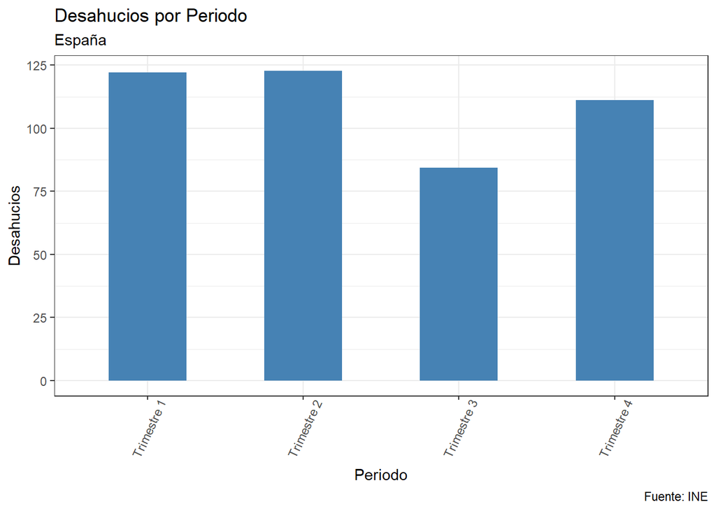

```r
# Draw plot
g2 <- ggplot(DBDesahucios, aes(x=Periodo, y=Desahucios)) +
  geom_bar(stat="identity", width=.5, fill="steelblue") +
  labs(title="Desahucios por Periodo",
       subtitle="España",
       caption="Fuente: INE") +
  theme(axis.text.x = element_text(angle=65, vjust=0.6))
g2
```

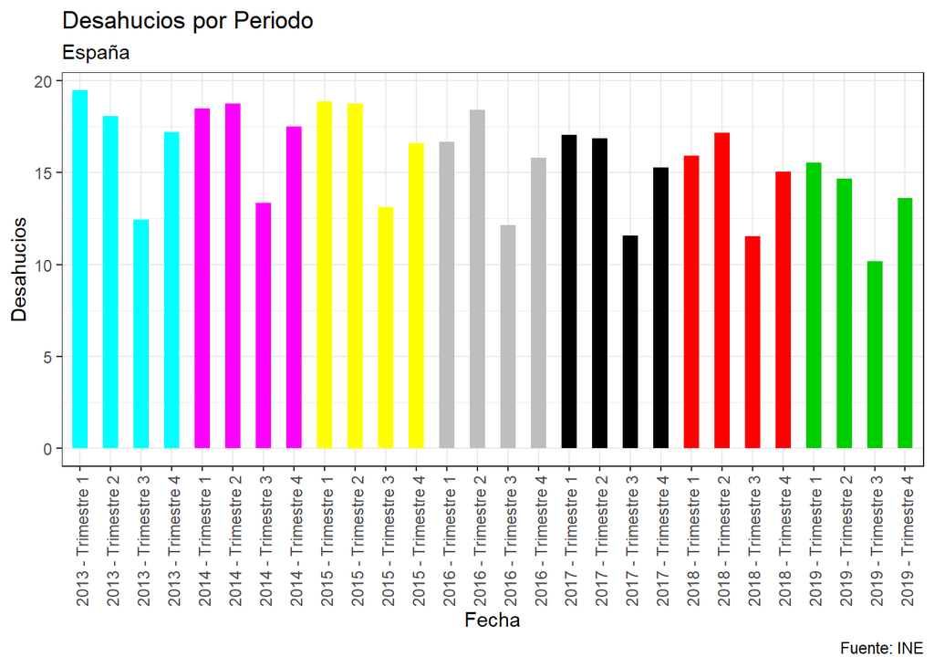

```r
g3 <- ggplot(DBDesahucios, aes(x=Fecha, y=Desahucios)) +
  geom_bar(stat="identity", width=.5, fill=Anyo) +
  labs(title="Desahucios por Periodo",
       subtitle="España",
       caption="Fuente: INE") +
  theme(axis.text.x = element_text(angle=90, vjust=0.6))
g3
```

#### Vamos a valorar la estacionalidad de la serie:

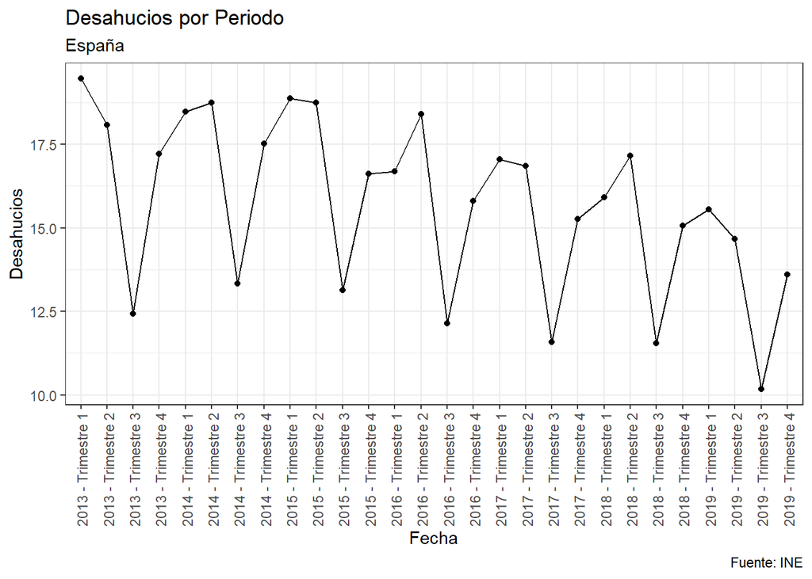

```r
library(ggplot2)
ggplot(data = DBDesahucios, aes(x=Fecha, y=Desahucios, group = 1)) + geom_line() +
         geom_point() +
  labs(title="Desahucios por Periodo",
       subtitle="España",
       caption="Fuente: INE") +
  theme(axis.text.x = element_text(angle=90, vjust=0.6))
```

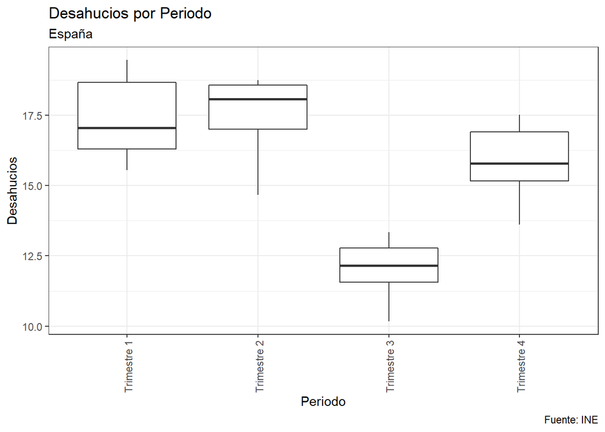

```r
ggplot(data = DBDesahucios) + geom_boxplot(aes(x=Periodo, y=Desahucios)) +
  labs(title="Desahucios por Periodo",
       subtitle="España",
       caption="Fuente: INE") +
  theme(axis.text.x = element_text(angle=90, vjust=0.6))
```

- En esta serie se observa claramente que hay un patrón similar que se repite año tras año. En el diagrama de cajas vemos como el tercer trimestre se produce una bajada de los deshacuios, mientras que en el segundo se alcanza el nivel mas alto.

## Modelo Holt-Winters:

Vamos a aplicar un Suavizado exponencial triple, un modelo de Holt-Winters para poder incluir la estacionalidad en el modelo. Tenemos dos principales modelos, dependiendo del tipo de estacionalidad:

- El modelo aditivo estacional: Un modelo de datos en el que los efectos de los factores individuales se diferencian y se agrupan para modelar los datos. Un modelo aditivo es opcional para los procedimientos de descomposición y para el método de Winters.
- El modelo multiplicativo estacional: Este modelo presupone que a medida que se incrementan los datos, también se incrementa el patrón estacional. La mayoría de las gráficas de series de tiempo muestran este patrón. En este modelo, la tendencia y los componentes de estación se multiplican y luego se suman al componente de error.
- *El modelo aditivo estacional*:

$\hat{x}_t = L_{t-1}+T_{t-1}+S_{t-c}$

```r
attach(DBDesahucios)
Desahucios_ts <- ts(Desahucios,start=c(2013,1),end=c(2019,4),frequency=4)
insample <- window(Desahucios_ts,start=c(2013,1),end=c(2018,4))
      # ajuste desde (2013,1) hasta 2018,4
outsample <- window(Desahucios_ts,start=c(2019,1),end=c(2019,4))
      # utilizamos 2019 para valorar predicción

#Aditiva:

fitDesahucios_aditivo <- HoltWinters(insample,seasonal="additive")
fitDesahucios_aditivo$coefficients
```

```
##           a           b          s1          s2          s3          s4
## 15.00030978 -0.04730347  1.09522156  1.99879577 -3.62261679  0.06808333
```

```r
#Parámetros del modelo
fitDesahucios_aditivo$alpha
```

```
##     alpha
## 0.3921367
```

```r
fitDesahucios_aditivo$beta
```

```
##      beta
## 0.3148246
```

```r
fitDesahucios_aditivo$gamma
```

```
##    gamma
## 0.585182
```

```r
fitval_aditivo <- fitted(fitDesahucios_aditivo)
fitval_aditivo
```

```
##             xhat    level       trend      season
## 2014 Q1 18.32746 16.50019  0.11252500  1.71475000
## 2014 Q2 18.63359 16.67449  0.13197368  1.82712500
## 2014 Q3 12.82457 16.85172  0.14622186 -4.17337500
## 2014 Q4 18.04193 17.20045  0.20997775  0.63150000
## 2015 Q1 19.12003 17.20419  0.14504920  1.77078777
## 2015 Q2 19.23304 17.25081  0.11405826  1.86817849
## 2015 Q3 13.23452 17.17113  0.05306666 -3.98967420
## 2015 Q4 17.67037 17.18517  0.04078001  0.44442040
## 2016 Q1 18.40460 16.81249 -0.08938668  1.68149312
## 2016 Q2 17.44213 16.05075 -0.30106138  1.69244250
## 2016 Q3 11.91845 16.12609 -0.18256135 -4.02507593
## 2016 Q4 15.94869 16.03354 -0.15422250  0.06936919
## 2017 Q1 16.71848 15.81984 -0.17294904  1.07159168
## 2017 Q2 17.68132 15.77885 -0.13140408  2.03387838
## 2017 Q3 11.14864 15.32498 -0.23292349 -3.94342278
## 2017 Q4 15.09747 15.26160 -0.17954628  0.01541216
## 2018 Q1 16.17709 15.14540 -0.15960475  1.19129578
## 2018 Q2 16.42830 14.87988 -0.19294864  1.74136902
## 2018 Q3 11.07749 14.97072 -0.10360513 -3.78962624
## 2018 Q4 15.07846 15.05123 -0.04564220  0.07286997
```

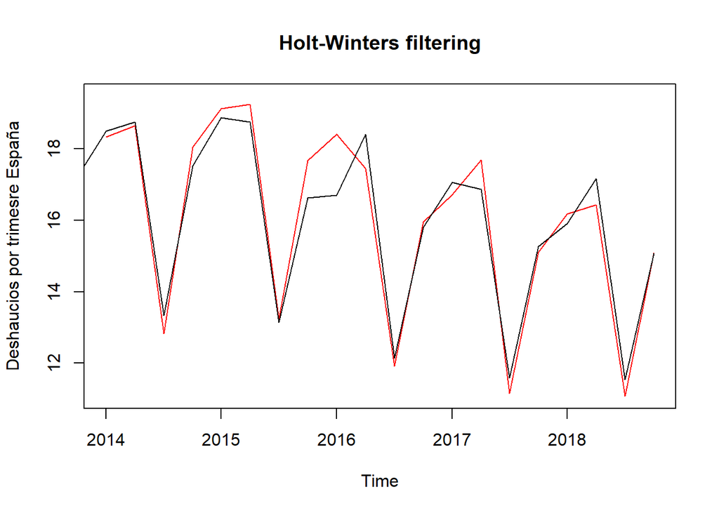

```r
plot(fitDesahucios_aditivo,ylab="Deshaucios por trimesre España")
```

```r
# Valoramos la bondad del ajuste
insamplecut <- window(insample,start=c(2014,1),end=c(2018,4))
rmse <- sqrt(mean((insamplecut-fitval_aditivo[,1])^2))
rmse
```

```
## [1] 0.6231713
```

```r
sqrt(fitDesahucios_aditivo$SSE/length(fitval_aditivo[,1]))
```

```
## [1] 0.6231713
```

```r
mape <- 100*mean(abs(insamplecut-fitval_aditivo[,1])/insamplecut)
mape
```

```
## [1] 2.973303
```

```r
# Predicción para el año 2019
pred <- predict(fitDesahucios_aditivo,4)
outsample;pred
```

```
##        Qtr1   Qtr2   Qtr3   Qtr4
## 2019 15.544 14.677 10.173 13.612
```

```
##          Qtr1     Qtr2     Qtr3     Qtr4
## 2019 16.04823 16.90450 11.23578 14.87918
```

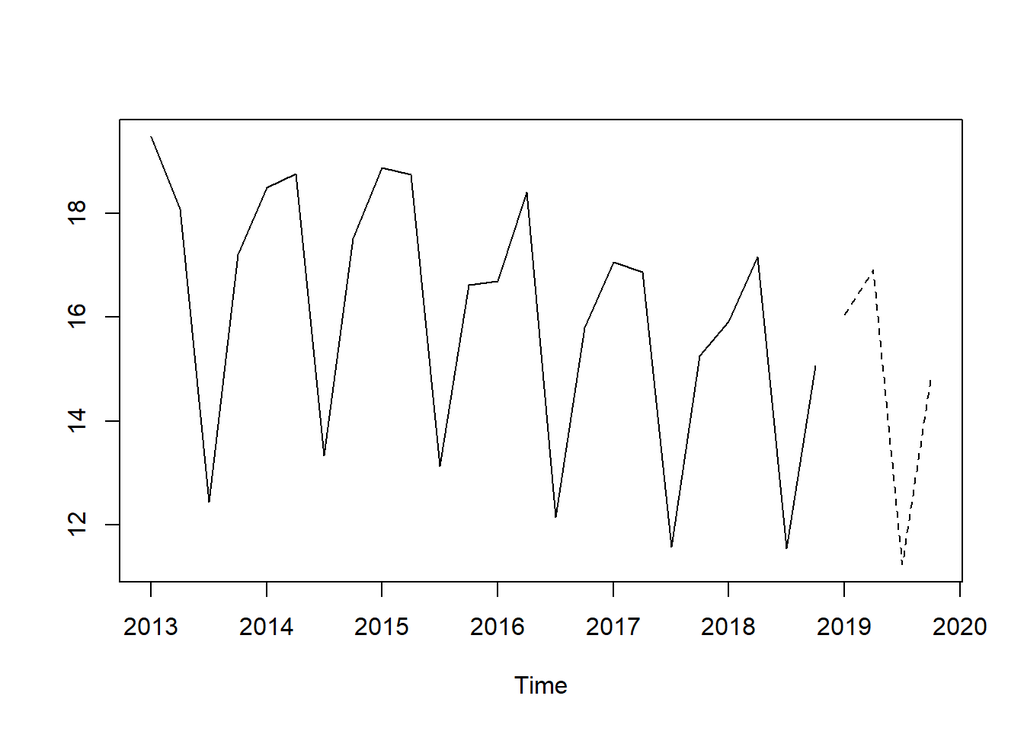

```r
ts.plot(insample,pred,lty=1:2)
```

```r
# Valoramos la capacidad predictiva del método

rmse_pred <- sqrt(mean((outsample-pred)^2))
rmse_pred
```

```
## [1] 1.409898
```

```r
mape_pred <- 100*mean(abs(outsample-pred)/outsample)
mape_pred
```

```
## [1] 9.544261
```

```r
#Estos valores nos seran de gran utilidad a la hora de comparar modelos y ver cuál es mejor.
```

Ahora vamos a ver los resultados con el *modelo multiplicativo estacional* y luego veremos si mejora el modelo respecto al aditivo estacional.

```r
attach(DBDesahucios)
Desahucios_ts <- ts(Desahucios,start=c(2013,1),end=c(2019,4),frequency=4)
insample <- window(Desahucios_ts,start=c(2013,1),end=c(2018,4))
      # ajuste desde (2013,1) hasta 2018,4
outsample <- window(Desahucios_ts,start=c(2019,1),end=c(2019,4))
      # utilizamos 2019 para valorar predicción

#multiplicativo:

fitDesahucios_multiplicativo <- HoltWinters(insample,seasonal="multiplicative")
fitDesahucios_multiplicativo$coefficients
```

```
##           a           b          s1          s2          s3          s4
## 14.98278623 -0.06753892  1.07092414  1.12443039  0.76393151  1.00585992
```

```r
fitDesahucios_multiplicativo$alpha
```

```
##     alpha
## 0.4344038
```

```r
fitDesahucios_multiplicativo$beta
```

```
##      beta
## 0.2692855
```

```r
fitDesahucios_multiplicativo$gamma
```

```
##     gamma
## 0.5459353
```

```r
fitval_multiplicativo <- fitted(fitDesahucios_multiplicativo)
fitval_multiplicativo
```

```
##             xhat    level       trend    season
## 2014 Q1 18.32477 16.50019  0.11252500 1.1030573
## 2014 Q2 18.63413 16.67581  0.12951691 1.1088227
## 2014 Q3 12.73211 16.85033  0.14163538 0.7493017
## 2014 Q4 18.26415 17.34497  0.23669353 1.0388183
## 2015 Q1 19.26833 17.26881  0.15244597 1.1060241
## 2015 Q2 19.30195 17.26441  0.11021133 1.1109277
## 2015 Q3 13.07856 17.15449  0.05093371 0.7601413
## 2015 Q4 17.73736 17.23768  0.05961992 1.0254408
## 2016 Q1 18.41063 16.82227 -0.06830108 1.0988821
## 2016 Q2 17.41711 16.07377 -0.25146650 1.1007946
## 2016 Q3 12.22728 16.21097 -0.14680491 0.7611523
## 2016 Q4 15.93698 16.01892 -0.15898893 1.0048578
## 2017 Q1 16.65265 15.79942 -0.17528406 1.0658286
## 2017 Q2 17.52886 15.78812 -0.13112469 1.1195543
## 2017 Q3 11.54322 15.39708 -0.20111623 0.7596242
## 2017 Q4 15.05415 15.21757 -0.19529884 1.0021221
## 2018 Q1 16.04070 15.11107 -0.17138650 1.0736976
## 2018 Q2 16.25957 14.88559 -0.18595324 1.1061207
## 2018 Q3 11.37434 15.05012 -0.09157378 0.7603907
## 2018 Q4 15.08674 15.05718 -0.06501132 1.0063080
```

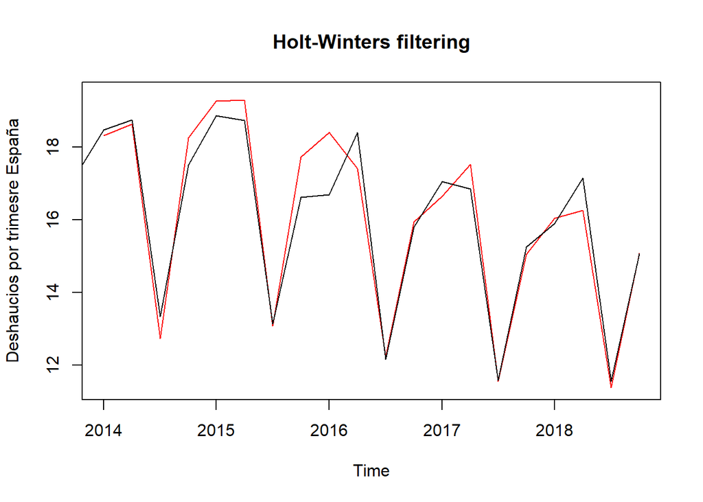

```r
plot(fitDesahucios_multiplicativo,ylab="Deshaucios por trimesre España")
```

```r
# Valoramos la bondad del ajuste
insamplecut <- window(insample,start=c(2014,1),end=c(2018,4))
rmse <- sqrt(mean((insamplecut-fitval_multiplicativo[,1])^2))
rmse
```

```
## [1] 0.6388035
```

```r
sqrt(fitDesahucios_multiplicativo$SSE/length(fitval_multiplicativo[,1]))
```

```
## [1] 0.6388035
```

```r
mape <- 100*mean(abs(insamplecut-fitval_multiplicativo[,1])/insamplecut)
mape
```

```
## [1] 2.774906
```

```r
# Predicción para el año 2019
pred <- predict(fitDesahucios_multiplicativo,4)
outsample;pred
```

```
##        Qtr1   Qtr2   Qtr3   Qtr4
## 2019 15.544 14.677 10.173 13.612
```

```
##          Qtr1     Qtr2     Qtr3     Qtr4
## 2019 15.97310 16.69521 11.29104 14.79885
```

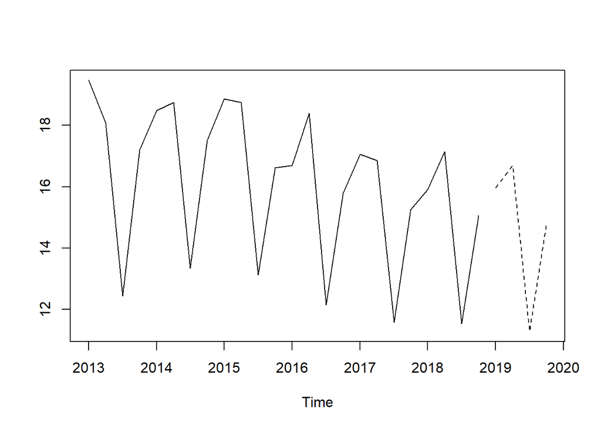

```r
ts.plot(insample,pred,lty=1:2)
```

```r
# Valoramos la capacidad predictiva del método

rmse_pred <- sqrt(mean((outsample-pred)^2))
rmse_pred
```

```
## [1] 1.314907
```

```r
mape_pred <- 100*mean(abs(outsample-pred)/outsample)
mape_pred
```

```
## [1] 9.055189
```

#### Valoración:

- Vemos que el modelo multiplicativo nos ofrece una menor tasa de error respecto al aditivo. Vemos que el RMSE del multiplicativo es de 1.314907 y la del aditivo de 1.4098, como vemos, un poco menor la del multiplicativo. También ocurre lo mismo en el MAPE. Entonces, selecciono el modelo multiplicativo estacional.

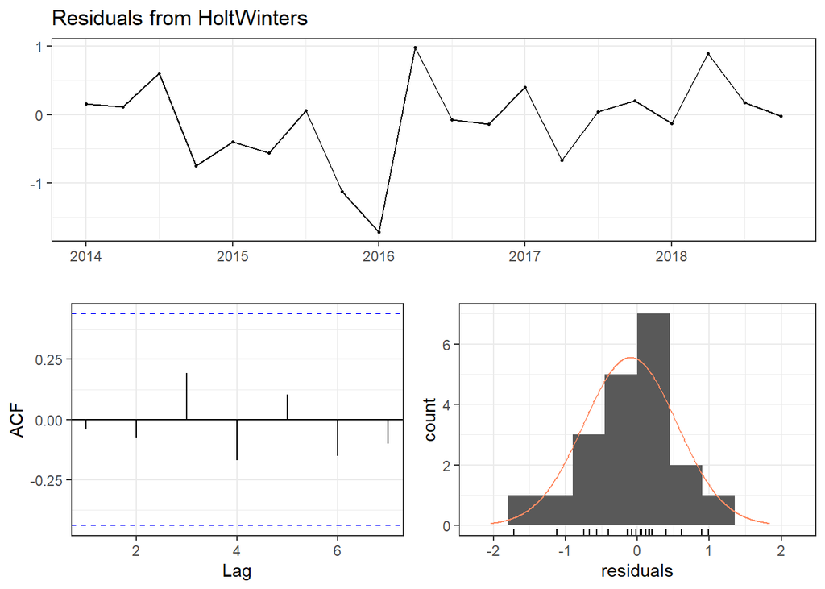

```r
library(forecast)
checkresiduals(fitDesahucios_multiplicativo)
```

```r
#Vemos que los residuos estan dentro de nuestro modelo, no hay picos en la gràfica que nos generen puntas en el histograma (colas más pesadas). Por lo que el modelo esta bastante bien.
```

## Análisis con el método sARIMA

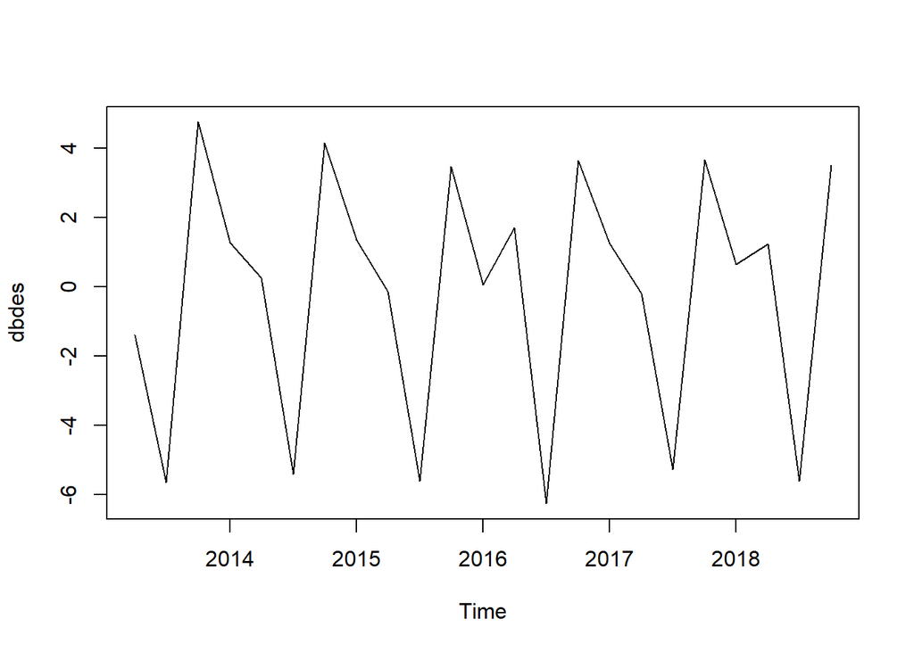

```r
Desahucios_ts <- ts(Desahucios,start=c(2013,1),end=c(2019,4),frequency=4)
insample <- window(Desahucios_ts,start=c(2013,1),end=c(2018,4))
      # ajuste desde (2013,1) hasta 2018,4
outsample <- window(Desahucios_ts,start=c(2019,1),end=c(2019,4))
      # utilizamos 2019 para valorar predicción

dbdes <- diff(insample) # Serie diferenciada una vez
plot(dbdes,type="l")
```

Hemos quitado la tendencia con la diferencia regular, pero aún queda la estacionalidad.

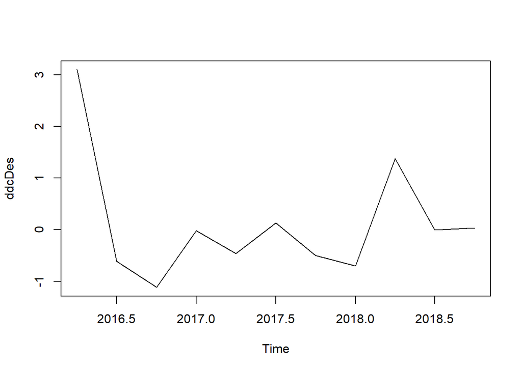

```r
ddcDes <- diff(dbdes,12) # Diferencia estacional
plot(ddcDes,type="l")
```

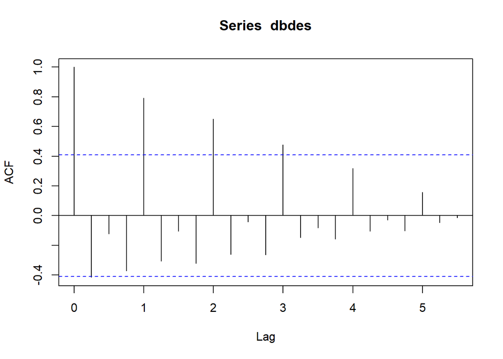

```r
acf(dbdes,lag.max=50)
```

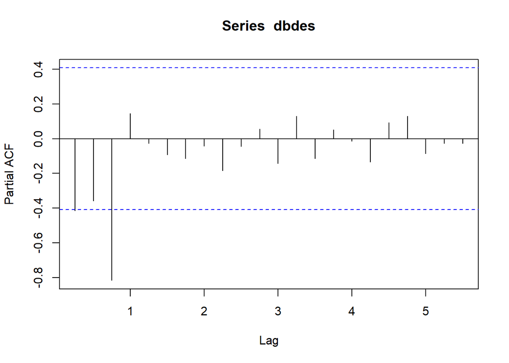

```r
pacf(dbdes,lag.max=50)
```

Vamos a seleccionar de manera automática el modelo (s)ARIMA que mejor se ajusta a la serie temporal de estudio con la función auto.arima:

```r
des_sarima <- auto.arima(insample)
des_sarima
```

```
## Series: insample
## ARIMA(0,0,1)(1,1,0)[4] with drift
##
## Coefficients:
##          ma1     sar1    drift
##       0.5206  -0.6223  -0.1119
## s.e.  0.2327   0.1673   0.0329
##
## sigma^2 estimated as 0.4048:  log likelihood=-18.89
## AIC=45.78   AICc=48.45   BIC=49.77
```

```r
accuracy(des_sarima)
```

```
##                      ME      RMSE       MAE       MPE     MAPE      MASE
## Training set 0.03362687 0.5355058 0.3888902 0.1456349 2.435754 0.5816485
##                     ACF1
## Training set -0.01887181
```

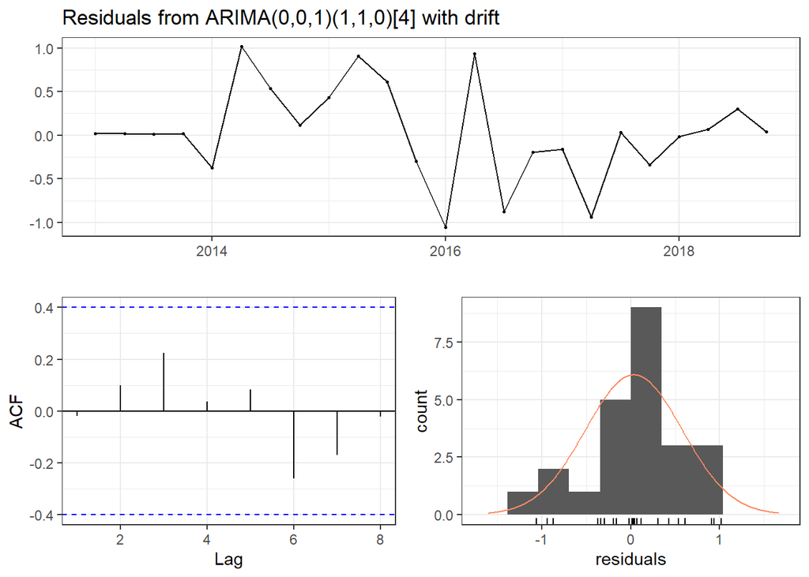

```
##
##  Ljung-Box test
##
## data:  Residuals from ARIMA(0,0,1)(1,1,0)[4] with drift
## Q* = 4.3857, df = 3, p-value = 0.2227
##
## Model df: 3.   Total lags used: 6
```

```r
checkresiduals(des_sarima,plot=TRUE)
```

En el checkresiduals podemos comprovar que no hace falta crear un modelo GARCH o ARCH donde se crearia un modelo que explicara la varianza residual. Obtenemos buenos resultados.

```r
pred <- forecast(des_sarima,h=5)$mean
pred
```

```
##          Qtr1     Qtr2     Qtr3     Qtr4
## 2019 15.91572 16.24362 10.84211 14.45968
## 2020 15.18424
```

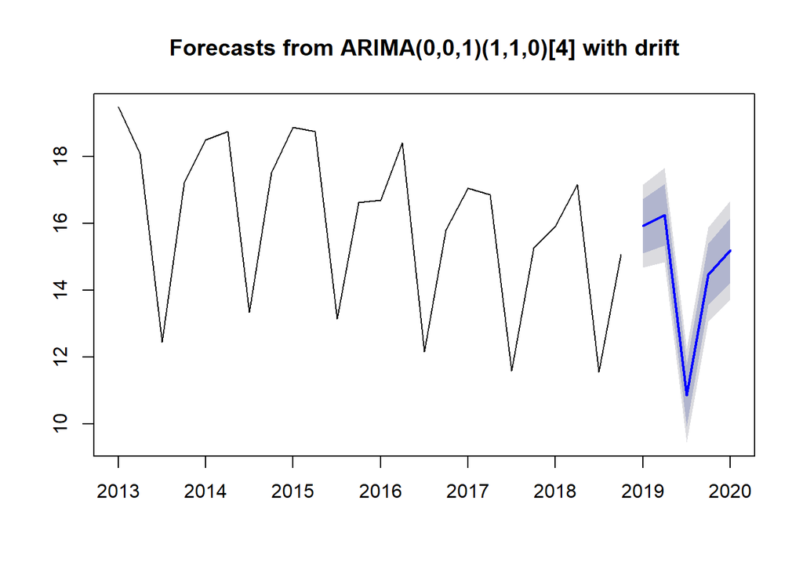

```r
plot(forecast(des_sarima,h=5))
```

Vemos que las predicciones del modelo son bueno.

```r
rmse_pred <- sqrt(mean((outsample-pred)^2))
rmse_pred
```

```
## [1] 0.969372
```

```r
mape_pred <- 100*mean(abs(outsample-pred)/outsample)
mape_pred
```

```
## [1] 6.467525
```

Vemos que con este modelo la mejora respecto a les de Holt-Winters es bastante. Mejora los errores de las predicciones. Ahora mismo, es el mejor modelo. Pero vamos a ver que pasa si utilizamos una red neuronal para hacer las predicciones:

## Modelo NAR: Red neuronal autorregresiva no lineal

- Entre los modelos no lineales que se han propuesto encontramos, por ejemplo, las redes neuronales autorregresivas (neural network autoregression, NNAR), también conocidas como modelos autorregresivos no lineales (nonlinear autoregressive, NAR

```r
attach(DBDesahucios)
library(forcats)
Desahucios_ts <- ts(Desahucios,start=c(2013,1),end=c(2019,4),frequency=4)
insample <- window(Desahucios_ts,start=c(2013,1),end=c(2018,4))
      # ajuste desde (2013,1) hasta 2018,4
outsample <- window(Desahucios_ts,start=c(2019,1),end=c(2019,4))
      # utilizamos 2019 para valorar predicción

fit.nar <- nnetar(insample)
fit.nar
```

```
## Series: insample
## Model:  NNAR(2,1,2)[4]
## Call:   nnetar(y = insample)
##
## Average of 20 networks, each of which is
## a 3-2-1 network with 11 weights
## options were - linear output units
##
## sigma^2 estimated as 0.2349
```

```r
accuracy(fit.nar)
```

```
##                        ME      RMSE       MAE         MPE     MAPE      MASE
## Training set 0.0005931559 0.4846208 0.3576667 -0.09690931 2.196503 0.5349486
##                   ACF1
## Training set 0.0966597
```

[figure not shown]

```r
fitval <- fitted.values(fit.nar)

plot(WWWusage,xlab="Minuto",ylab="Usuarios conectados")
lines(fitval, col="blue")
abline(v=95)
```